# DataCamp Certification Case Study

### Project Brief

You are on the data science team for a coffee company that is looking to expand their business into Ukraine. They want to get an understanding of the existing coffee shop market there.

You have a dataset from Google businesses. It contains information about coffee shops in Ukraine. The marketing manager wants to identify the key coffee shop segments. They will use this to construct their marketing plan. In their current location, they split the market into 5 segments. The marketing manager wants to know how many segments are in this new market, and their key features.

You will be presenting your findings to the Marketing Manager, who has no data science background.

The data you will use for this analysis can be accessed here: `"data/coffee_shops.csv"`

## Ukranian Coffee Shops: New Market Customer Segments

### Prepared by Donovan Doyle

I just wanted to say I appreciate the time, feel free to pass this along to anybody on the marketing team who couldn’t make the meeting. To quickly brief on this, we’re looking at the Ukranian coffee market and how we want to segment our customers in our expansion. We used data from Google Business Reviews, as well as population data from the United Nations and the World Population Review.

To briefly summarize what our findings, there are 4 customer segments we’d like to focus on. With the data from existing coffee shops and the regions, we’re able to differentiate those customer segments based on their current taste in the coffee market.

I can walk through how we explored the data, some interesting trends that we found, the model we built to establish these 4 customer segments, and what makes them different. These four segments are differentiated as coffee drinkers who prefer Quality, Luxury coffee drinkers, Convenience coffee drinkers, and Hidden Gem coffee drinkers, which I can dive more into later.

## Summary Statistics: Understanding the Market

We’re looking at 10 different regions, with 20 coffee providers located in each region.

### Population Breakdown

It would first be helpful to get an understanding of the regions provided. If certain areas are city environments and heavily concentrated, we should note that.

Figure 1: Population and Density by Region

| Region | Population (millions) | Population Density (people per km-squared) |
| --- | --- | --- |
| Kiev | 2.88 | 3299 |
| Kharkiv | 1.43 | 4500 |
| Odessa | 0.99 | 6139 |
| Dnipro | 0.98 | 2411 |
| Zaporozhye | 0.72 | 1365 |
| Lviv | 0.72 | 4000 |
| Khrivoy Rog | 0.61 | 1425 |
| Mariupol | 0.43 | 1800 |
| Kherson | 0.28 | 2090 |
| Poltava | 0.28 | 2800 |

This shows us that the bigger city areas are Kiev, Kharkiv, and Odessa. While it’s sorted by population, Lviv is a more densely-populated area as well. This can provide context to trends we see on a reginoal level.

### Coffee Shops in each Region

Now we can dive more specifically into the make-up of the coffee shops in each of these regions.

Figure 2: Coffee Shops by Region

| Region | Average Rating | Service Options Shops with Delivery | Service Options Shops with Dine-In | Service Options Shops with Takeout |
| --- | --- | --- | --- | --- |
| Kiev | 4.78 | 3 | 12 | 11 |
| Odessa | 4.78 | 4 | 13 | 9 |
| Mariupol | 4.70 | 4 | 14 | 19 |
| Lviv | 4.67 | 3 | 19 | 20 |
| Zaporozhye | 4.67 | 3 | 11 | 10 |
| Poltava | 4.66 | 4 | 12 | 13 |
| Kherson | 4.64 | 3 | 12 | 17 |
| Khrivoy Rog | 4.60 | 5 | 16 | 17 |
| Kharkiv | 4.58 | 2 | 14 | 13 |
| Dnipro | 4.55 | 4 | 17 | 15 |

This is arranged by highest average rating, with Kiev’s shops scoring the highest. Looking at the service options, it seems common for shops to have take-out options, but very few deliver.

### Differences in the Regions

We want to contextualize the average rating as well, as we don’t know how “different” of a rating 4.78, the highest by region, is from 4.55, the lowest. We can take just the top 2 regions and the bottom 2 regions, and compare them side-by-side.

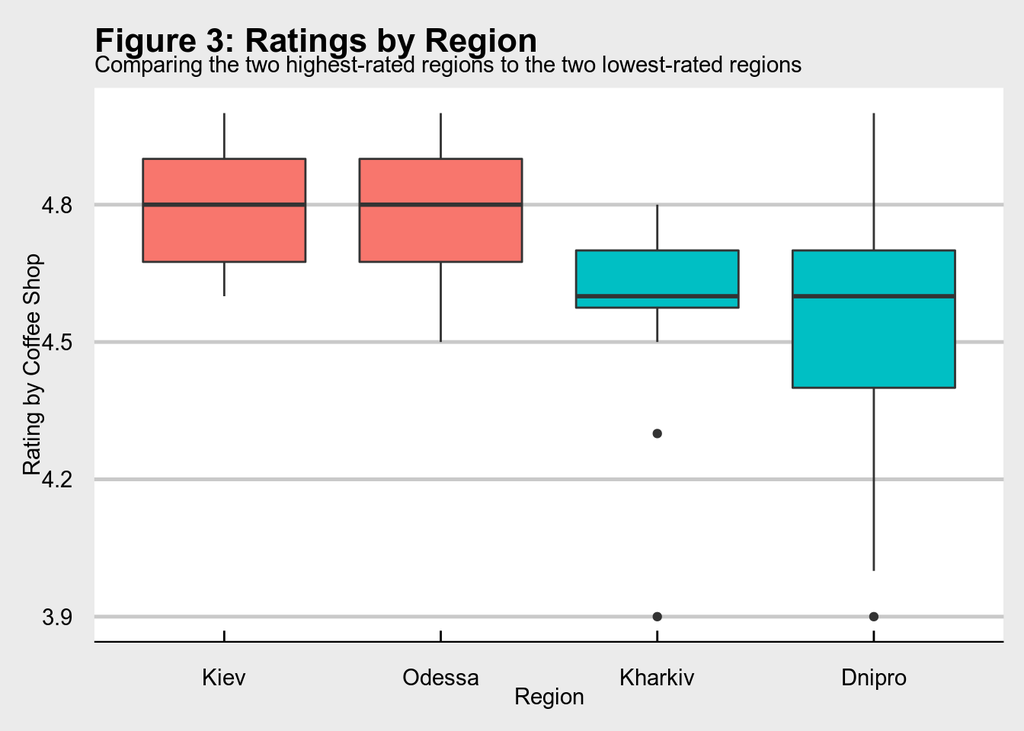

There does seem to be a stark difference between the ratings by region, so we need to be aware of this. This infers there is differentiation by region in the Ukraine, as some seem to be more saturated with already-successful coffee shops.

### Service Options and their Impact

We can look at how the different service options affect ratings. The question we’re trying to answer is: Do coffee shops who provide multiple services see better ratings from their customers?

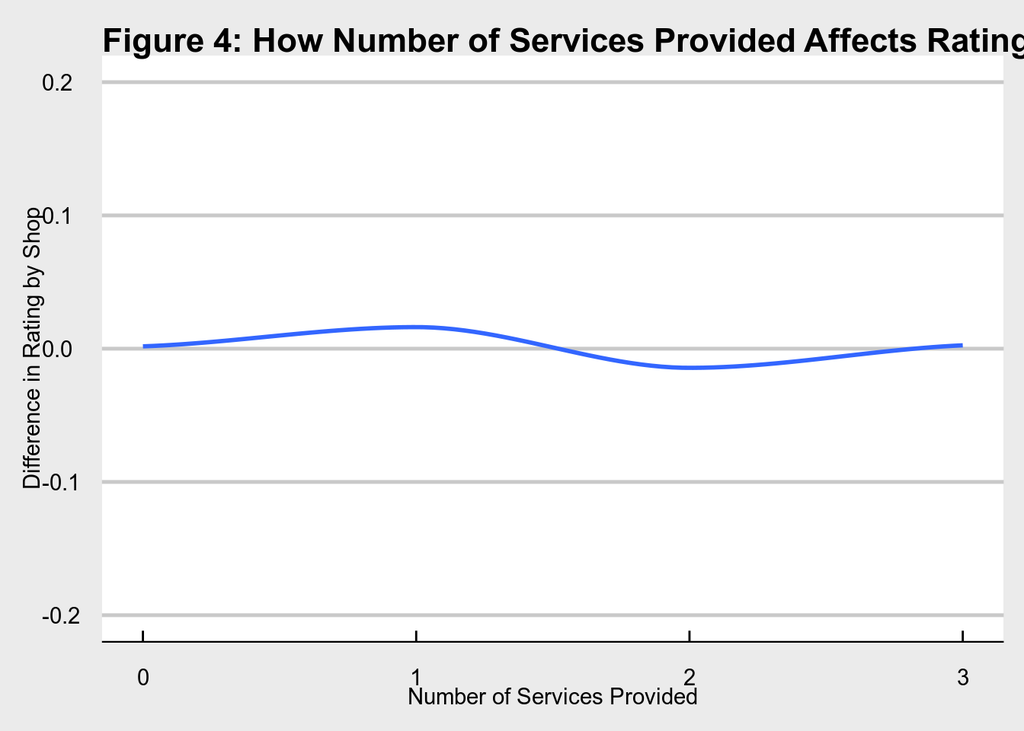

To do this, we can look at the correlation between services provided to average rating. As number of services provided increases, there seems to be no correlation at all with the average rating. Service options isn’t something we really need to focus on in terms of our business expansion. We can also see Is there a specific type of service that does have an impact?

Figure 5: How Each Option Affects Rating

| Delivery Option | Takeout Option | Dine-In Option |
| --- | --- | --- |
| -0.01 | -0.08 | -0.04 |

This shows that no matter what the service options are, it has basically no effect, as these are all close to zero. This uncovers that coffee shops who are doing well in Ukraine aren’t necessarily providing the most options; other aspects, such as brand loyalty are at play.

### Summary Findings

By exploring this data at an observatory level, we can conclude a few things:

1. There’s a difference in geography: There is variance, we can’t treat Ukraine as a homogeneous state.
2. Within that geography, the coffee market is different as well: There are regions already with a strong coffee culture.
3. Services have little to no impact on rating scores

We now have a strong understanding of the current state of the coffee market in the Ukraine and how we can establish our customer segments in the market.

## Identifying Customer Segments: How Many and Who?

While we currently operate with 5 customer segments in mind, this may not be the case in the Ukraine. We need to determine how many different segments exist, and what makes them different.

Now looking at the Optimal number of clusters graph, we get into the actual modeling– this graph is as technical as I’m going to get, but you can think of the X-axis as potential number of segments, and the Y-axis as how effective the model is.

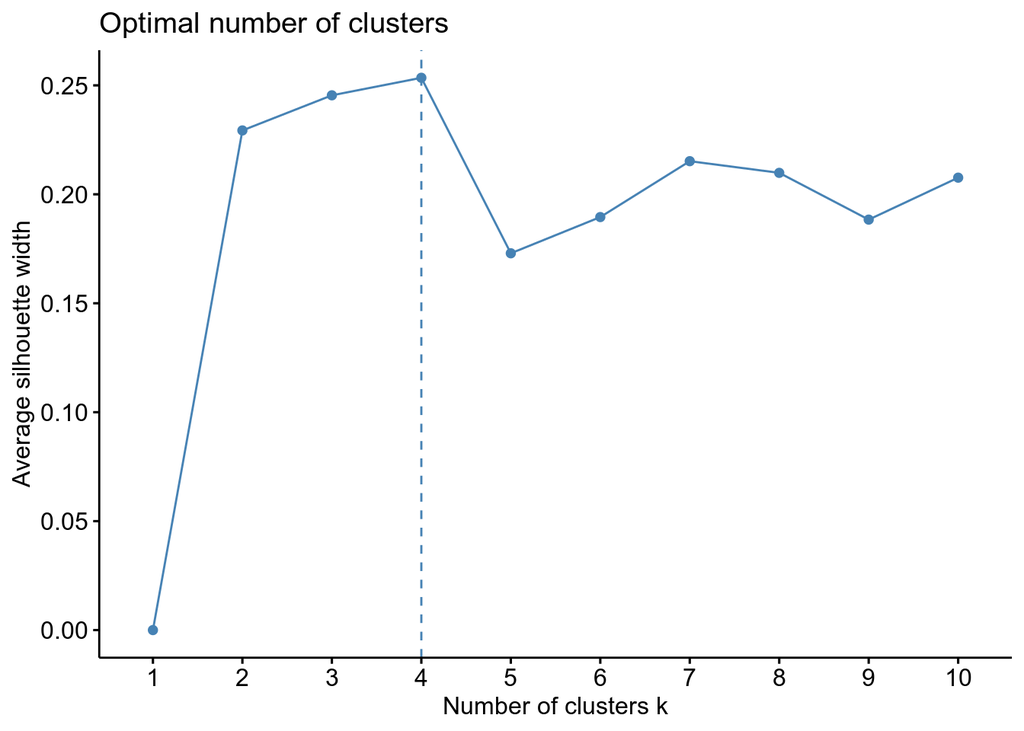

This pintpoints that the optimal number of segments for our model will be 4 distinct segments, shown by the dotted line.

We can now actually segment our existing data by coffee shop into the 4 clusters, and see what those segments have in common. We’ll do this through a machine learning model called “K-means clustering”, also as technical as I’m going to get, to simplify, this essentially grouping the shops into four groups by characteristics in the data. By grouping the shops, we can learn about the customers who go to each.

## The Four Customer Segments

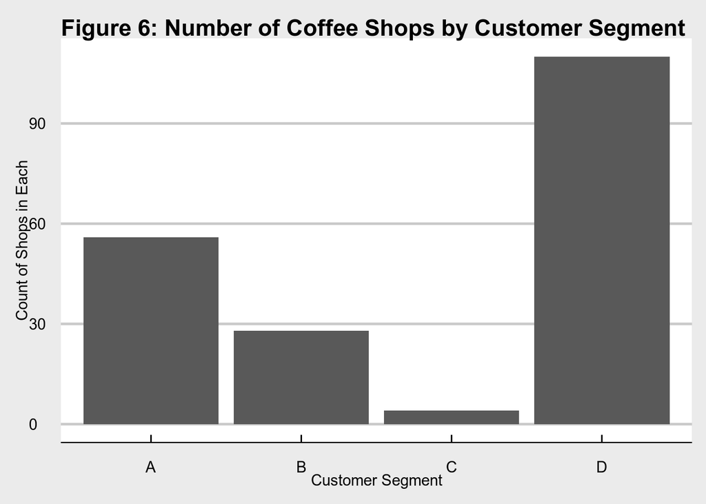

Moving past that, We still need to differentiate these four segments and can still apply our model to do this.

Looking at Figure 6 still, the customer segment here that is clearly differentiated is C. When taking a quick pass at the data in Segment C, it includes every shop with an expensive price rating, meaning these are our expensive-taste coffee drinkers. This is a valuable customer segment and we do need to make the distinction. Only 4 shops were labeled with this expensive title, hence the low number in this segment.

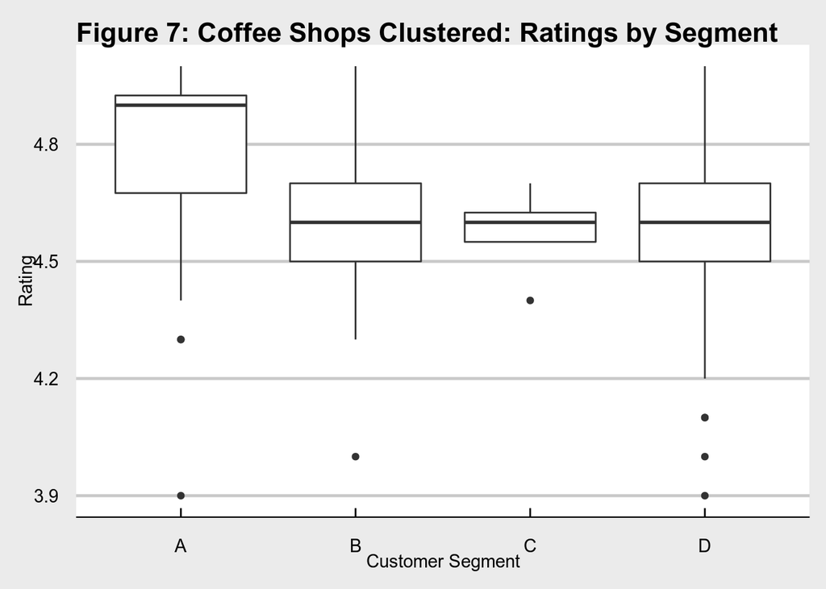

Now looking at Figure 7, we can divide each customer segment by their average rating. This now helps us identify what Segment A is: our high-rating coffee drinkers. These shops receive very positive reviews, and seem to attract a specific type of customer, so we can group them together under that label of high-rating coffee drinkers.

So this leaves us with two segments left to identify: B and D.

There are two more areas we can look: review count and service options. We can use review count as a proxy for popularity, since the more people who go to a coffee shop, the more likely they are to leave a review, so we should see higher review numbers. One of our segments could be those who like coffee shops that are considered popular and have high-traffic.

Figure 8: Customer Segment by Popularity - Average Reviews per Shop

| Customer Segment | Average Number of Reviews per Shop |
| --- | --- |
| A | 107.0 |
| B | 1539.6 |
| C | 1132.8 |
| D | 632.9 |

What differentiates Segment D then? We can go back to the service options, because it may not impact the shop ratings, but could attract a specific type of customer.

Figure 9: Services Offered by Customer Segment

| Customer Segment | Service Options Shops with Delivery | Service Options Shops with Dine-In | Service Options Shops with Takeout | Average Services Offered by Shop |
| --- | --- | --- | --- | --- |
| A | 5 | 8 | 14 | 0.5 |
| B | 28 | 27 | 22 | 2.8 |
| C | 2 | 4 | 4 | 2.5 |
| D | 0 | 101 | 104 | 1.9 |

Looking at Figure 9, this helps paint the picture of who is in our Customer Segment D. While there are over 100 shops that fit into Segment D, *none* of them have a delivery service, and nearly every single one has both dine-in and take-out options. We can infer that this means they’re more cafe-style, “sit down and do your work” locations, or quick places, like an espresso bar.

## Results

Tying this all together, This is what we really came here for. We’ve identified four customer segments, characterized as follows:

- Segment A: **Quality Coffee Drinkers**. This segment is attracted to coffee with the highest ratings, even if they’re not the most popular in terms of review count.
- Segment B: **Convenience Coffee Drinkers**. This segment enjoys bustling, highly-frequented coffee shops–think of the nearest Starbucks by your office.
- Segment C: **Luxury Coffee Drinkers**. This segment is the smallest, again, important to distinguish as its own segment.
- Segment D: **Hidden Gem Coffee Drinkers**. This segment enjoys the quieter, smaller shops that are a bit more bare-bones, as they don’t deliver.

### Future Initiatives and Limitations

As we continue to explore our expansion into Ukraine, we can build on this model and execute well. Some things we’d like to see include:

- **Survey Data**: It would be valuable to gather some data first-hand, as opposed to evaluating existing coffee shop data.
- **More Robust Population Analysis**: additionally, we want to know who is actually drinking coffee in the Ukrarine? Is it high-income individuals, or those who live in cities?
- **Price Analysis**: Pricing is a huge opportunity in the market, and it would be helpful to gather what these coffee shops are actually charging and how we compare.

There were a few issues to work through in the data provided. The most prevalent were:

- **Missing Price Data**: We didn’t have price data for nearly half of those included in the dataset, which is why we recommend moving forward with the price analysis project.
- **Missing Delivery Data**: we treated shops with missing delivery data as not having a delivery option. This seemed to be the logical solution, as shops who had delivery would likely be included to make sure that was shared online.
- **Data Source**: Google Business Reviews data should be viewed with a grain of salt and don’t necessarily reflect the customer experience.

Just to summarize, we’ve established our four customer segments and what makes those different, which will be hugely valuable as we move into Ukraine. We can continue to build out the models as we gather more information. I really appreciate the time, does anybody have questions?